# $\color{blue}{\text{Mon Projet de machine learning sur le titanic}}$

### Nom: Niah

### Prenom: Mouhammed

### Master: Ingenierie Mathematique et Numerique

# 1. Exploration des données

## Objectif :

- Comprendre le mieux possible nos données
- Developper une stratégie de modelisatin

## Checklist de Base

#### Analyse de forme

- **variable Target**: Survived
- ** **ligne et colonne**:(891, 15)
- ** **type de variable**: variable quantitative et varible qualitative
- ** **Analyse des valeur manquantes**: la plutpart des colonnes n'ont de valeur manquante considérable sauf pour la colonne age(dont 20% de ses valeurs sont manquante) et pour la colonne deck(dont 77% de ses valeur sont manquantes)

#### Analyse de fond

- **visualisation de target**: 38% on constate il n y avait que 38% de survie dans le titanic
- **signification des ariables**:

  ```
  • Survived : indique la mort ou la survie du passager pour l’apprentissage. C’est le vecteur
    à prédire pour le test. Le résultat est booléen : 1 pour « survie », 0 pour « mort ».
  • Pclass : la classe des chambres du navire, à 3 niveaux : 1 étant la meilleure, 3 la classe
     « éco » et 2 l’intermédiaire. C’est donc une variable catégorielle, mais qui pourrait être
       considérée comme ordonnée.
  • Sex : le sexe du passager. C’est une variable catégorielle à 2 modalités : « Male » et               « Female ».
  • Age : l’âge du passager, une variable continue avec valeurs manquantes.
  • SisbSp (Sibling and Spouse) : le nombre de membres de la famille du passager de type
  frère, sœur, demi-frère, demi-sœur, époux, épouse (une variable continue).
  • Parch (Parent and Child) : le nombre de membres de la famille du passager du type
  père, mère, fils, fille, beau-fils, belle-fille (également une variable continue).
  • Ticket : le numéro du ticket, une variable catégorielle.
  • Fare : le prix du ticket, une variable continue.
  • Embarked : le port d’embarquement du passager, une variable catégorielle à 3 modalités
  ```

- **Relation Target\Variable** :il semblerait que le Target **survived**est lié à la variable **pclass**, **sex**

```python
# importation des modules
import pandas as pd
import seaborn as sns
import matplotlib.pyplot as plt
import numpy as np
```

```python
df=sns.load_dataset('titanic')
```

### Analyse de forme

```python
df.head()
```

|  | survived | pclass | sex | age | sibsp | parch | fare | embarked | class | who | adult_male | deck | embark_town | alive | alone |
| --- | --- | --- | --- | --- | --- | --- | --- | --- | --- | --- | --- | --- | --- | --- | --- |
| 0 | 0 | 3 | male | 22.0 | 1 | 0 | 7.2500 | S | Third | man | True | NaN | Southampton | no | False |
| 1 | 1 | 1 | female | 38.0 | 1 | 0 | 71.2833 | C | First | woman | False | C | Cherbourg | yes | False |
| 2 | 1 | 3 | female | 26.0 | 0 | 0 | 7.9250 | S | Third | woman | False | NaN | Southampton | yes | True |
| 3 | 1 | 1 | female | 35.0 | 1 | 0 | 53.1000 | S | First | woman | False | C | Southampton | yes | False |
| 4 | 0 | 3 | male | 35.0 | 0 | 0 | 8.0500 | S | Third | man | True | NaN | Southampton | no | True |

```python
df.shape
```

```
(891, 15)
```

```python
df.dtypes.value_counts()
```

```
object      5
int64       4
float64     2
bool        2
category    1
category    1
dtype: int64
```

```python
df.isna().sum()/df.shape[0]
```

```
survived       0.000000
pclass         0.000000
sex            0.000000
age            0.198653
sibsp          0.000000
parch          0.000000
fare           0.000000
embarked       0.002245
class          0.000000
who            0.000000
adult_male     0.000000
deck           0.772166
embark_town    0.002245
alive          0.000000
alone          0.000000
dtype: float64
```

#### visualisation des valeurs manquantes

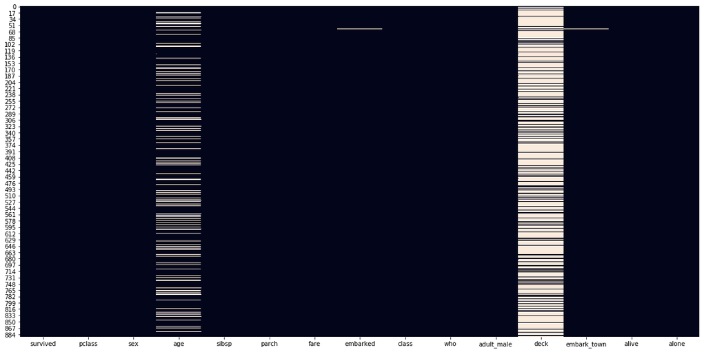

```python
plt.figure(figsize=(20,10))
sns.heatmap(df.isna(),cbar=False)
```

### Analyse de fond

```python
df['survived'].value_counts(normalize=True)
```

```
0    0.616162
1    0.383838
Name: survived, dtype: float64
```

#### creation de sous-ensembles survie et pas_survie du titanic

```python
df_survie=df[df['survived']==1]
df_pas_survie=df[df['survived']==0]
```

### Relation Target\Variable

#### $\color{red}{\text{Relation target \ fare}}$

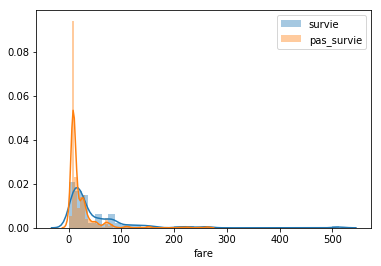

```python
plt.figure()
sns.distplot(df_survie['fare'],label='survie')
sns.distplot(df_pas_survie['fare'],label='pas_survie')
plt.legend()
```

#### $\color{red}{\text{Relation target \ age}}$

```python
df_survie['age'].value_counts()
```

```
24.00    15
36.00    11
35.00    11
27.00    11
22.00    11
30.00    10
19.00     9
32.00     9
18.00     9
29.00     8
31.00     8
28.00     7
4.00      7
34.00     6
42.00     6
26.00     6
40.00     6
16.00     6
25.00     6
48.00     6
33.00     6
17.00     6
23.00     5
1.00      5
50.00     5
45.00     5
21.00     5
3.00      5
38.00     5
39.00     5
         ..
54.00     3
58.00     3
52.00     3
2.00      3
44.00     3
60.00     2
13.00     2
56.00     2
9.00      2
51.00     2
63.00     2
6.00      2
62.00     2
8.00      2
0.83      2
41.00     2
0.75      2
37.00     1
47.00     1
0.42      1
0.92      1
11.00     1
53.00     1
55.00     1
43.00     1
80.00     1
7.00      1
32.50     1
12.00     1
0.67      1
Name: age, Length: 65, dtype: int64
```

```python
df_pas_survie['age'].value_counts()
```

```
21.0    19
28.0    18
25.0    17
18.0    17
22.0    16
19.0    16
30.0    15
24.0    15
29.0    12
20.0    12
26.0    12
36.0    11
16.0    11
23.0    10
32.0     9
31.0     9
39.0     9
34.0     9
33.0     9
47.0     8
45.0     7
42.0     7
40.0     7
2.0      7
35.0     7
27.0     7
17.0     7
38.0     6
44.0     6
9.0      6
        ..
10.0     2
64.0     2
58.0     2
70.0     2
8.0      2
59.0     2
57.0     2
71.0     2
62.0     2
45.5     2
60.0     2
30.5     2
40.5     2
56.0     2
49.0     2
24.5     1
6.0      1
34.5     1
15.0     1
66.0     1
55.0     1
3.0      1
23.5     1
20.5     1
14.5     1
74.0     1
32.5     1
36.5     1
55.5     1
70.5     1
Name: age, Length: 77, dtype: int64
```

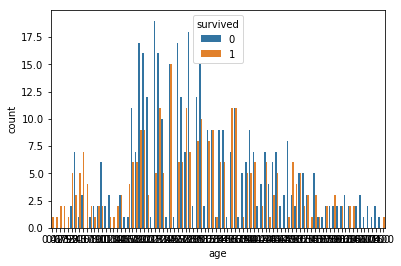

```python
sns.countplot(x='age',hue='survived',data=df)
```

#### $\color{blue}{\text{Commentaire}}$ :

#### Il est tres difficile de poser une hypothése concernant l'age et la survie des passagés du titanic car l'analyse de s'avére etre tres complexe

#### $\color{red}{\text{Relation target \ pclass}}$

```python
df_survie['pclass'].value_counts(normalize=True)
```

```
1    0.397661
3    0.347953
2    0.254386
Name: pclass, dtype: float64
```

```python
df_pas_survie['pclass'].value_counts(normalize=True)
```

```
3    0.677596
2    0.176685
1    0.145719
Name: pclass, dtype: float64
```

#### Visualisons ces données

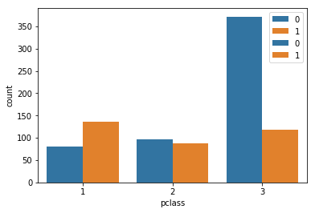

```python
plt.figure()
sns.countplot(x=df_survie['pclass'],hue='survived',data=df)
sns.countplot(x=df_pas_survie['pclass'],hue='survived',data=df)
plt.legend()
```

#### De meme 68% des morts etait dans la 3 place ,18% etait dans la 2 place et les 14% restant etait dans la 1 place

#### $\color{blue}{\text{hypothése}}$:

#### Il semblerait que la classe des passagers est lié a leurs survies

#### $\color{red}{\text{Relation Target \ sex}}$

```python
df_survie['sex'].value_counts(normalize=True)
```

```
female    0.681287
male      0.318713
Name: sex, dtype: float64
```

```python
df_pas_survie['sex'].value_counts(normalize=True)
```

```
male      0.852459
female    0.147541
Name: sex, dtype: float64
```

#### visualisons ces données

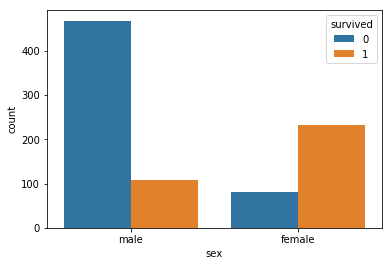

```python
sns.countplot(x=df['sex'],hue='survived',data=df)
```

#### On constate qu'on à plus de survivant et moins de mort chez les femmes que chez les hommes

#### $\color{blue}{\text{hypothése}}$:

#### D'aprés l'analyse on peut poser comme hypothése le fait que: le $\color{red}{\text{sex}}$ est lié à la survie des passagers du titanic

#### $\color{red}{\text{Relation Target \sibsp}}$

```python
df_survie['sibsp'].value_counts(normalize=True)
```

```
0    0.614035
1    0.327485
2    0.038012
3    0.011696
4    0.008772
Name: sibsp, dtype: float64
```

```python
df_pas_survie['sibsp'].value_counts(normalize=True)
```

```
0    0.724954
1    0.176685
4    0.027322
2    0.027322
3    0.021858
8    0.012750
5    0.009107
Name: sibsp, dtype: float64
```

#### Visualisons ces données

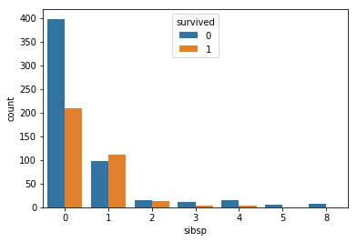

```python
sns.countplot(x=df['sibsp'],hue='survived',data=df)
```

#### $\color{red}{\text{Relation Target \ deck}}$

le nombre de valeur manquante de la variable **deck** est:

```python
df['deck'].isna().sum()
```

```
688
```

#### Ce nombre represente **77%** des valeurs de $\color{red}{\text{deck}}$ donc il serait très difficile de prouver que la variable $\color{red}{\text{deck}}$ ait une quelconque liaison avec la survie des passagers du tiatinic

#### $\color{red}{\text{Relation Target \ embarked}}$

##### visualisation des données

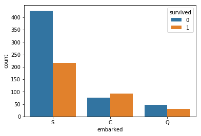

```python
sns.countplot(x=df['embarked'],hue='survived',data=df)
```

```python
df.head(5)
```

|  | survived | pclass | sex | age | sibsp | parch | fare | embarked | class | who | adult_male | deck | embark_town | alive | alone |
| --- | --- | --- | --- | --- | --- | --- | --- | --- | --- | --- | --- | --- | --- | --- | --- |
| 0 | 0 | 3 | male | 22.0 | 1 | 0 | 7.2500 | S | Third | man | True | NaN | Southampton | no | False |
| 1 | 1 | 1 | female | 38.0 | 1 | 0 | 71.2833 | C | First | woman | False | C | Cherbourg | yes | False |
| 2 | 1 | 3 | female | 26.0 | 0 | 0 | 7.9250 | S | Third | woman | False | NaN | Southampton | yes | True |
| 3 | 1 | 1 | female | 35.0 | 1 | 0 | 53.1000 | S | First | woman | False | C | Southampton | yes | False |
| 4 | 0 | 3 | male | 35.0 | 0 | 0 | 8.0500 | S | Third | man | True | NaN | Southampton | no | True |

### Relation Variables \Variables

### $\color{blue}{\text{on constate une grande similarité entre les variables}}$ :

#### - **la variable embaked est equivalente à la variable embarked_town**:

car on a remplacé le Southampton, Cherbourg,... du variable embarked_town par leurs premiers lettre à savoir S,C,... dans la variable embarked

#### - **la variable alive est equivalente à la variable survived**:

car la variable survived est l'encodage de la variable alive

#### - **la variable who est equivalente à la variable sex**:

les deux variables sont les même car les hommes sont de sex male et les femmes sont de sex female

#### - **la variable pclass est equivalent à la variable classe**:

car la variable pclass est l'encodage de la variable classe

## Strategie:

[output not shown]

```python
df.columns
```

```
Index([u'survived', u'pclass', u'sex', u'age', u'sibsp', u'parch', u'fare',
       u'embarked', u'class', u'who', u'adult_male', u'deck', u'embark_town',
       u'alive', u'alone'],
      dtype='object')
```

# 2.Prè-Traitement Et le Traitement de nos données

## Objectif:

- **Mettre nos données dans un format propice à la machine learning**:
  - Séparé nos données en Train \ test
  - l'encodage de nos données
  - Nétoyage des valeurs manquantes
  - $\color{red}{\text{Premier modèle: Evaluation - Diagnostique}}$
- **Améliorer la performance de notre modèle**:

```python
# le tableau obtenue apres l'exploration de nos données est en eliminant les variables qui n'ont pas
# un grand impct sur notre Target (survived)
df.drop(['sibsp', 'parch', 'fare',
       'embarked', 'class', 'who', 'adult_male', 'deck', 'embark_town',
       'alive', 'alone'],axis=1,inplace=True)
```

#### Nettoyage des valeurs maquantes

```python
df.dropna(axis=0,inplace=True)
```

```python
df.shape
```

```
(714, 4)
```

#### l'encodage de nos données

```python
df['sex'].replace(['female','male'],[1,0],inplace=True)
```

#### Séparation de nos données

```python
from sklearn.model_selection import train_test_split
```

```python
y=df['survived']
x=df.drop('survived',axis=1)
```

```python
x_train,x_test,y_train,y_test=train_test_split(x,y,test_size=0.2)
```

## Modelisation

```python
from sklearn.neighbors import KNeighborsClassifier
from sklearn.linear_model import SGDClassifier
```

```python
model=KNeighborsClassifier()
```

```python
model.fit(x_train,y_train)
model.predict(x_test)
```

```
array([0, 0, 1, 0, 0, 1, 1, 0, 1, 0, 0, 0, 0, 0, 1, 1, 1, 0, 0, 1, 0, 0,
       0, 0, 0, 0, 0, 0, 0, 0, 0, 0, 1, 0, 1, 0, 0, 0, 0, 0, 1, 0, 0, 1,
       0, 0, 0, 1, 0, 0, 0, 1, 0, 0, 0, 1, 0, 1, 0, 1, 1, 0, 0, 1, 1, 0,
       0, 1, 0, 0, 0, 0, 1, 0, 0, 0, 0, 0, 0, 0, 1, 1, 0, 0, 0, 0, 1, 0,
       0, 0, 0, 1, 0, 0, 1, 0, 0, 0, 0, 1, 0, 0, 0, 1, 0, 0, 1, 1, 0, 0,
       0, 0, 0, 1, 1, 0, 0, 0, 0, 1, 0, 0, 0, 0, 0, 0, 0, 1, 0, 0, 1, 0,
       0, 0, 0, 1, 1, 0, 0, 1, 0, 0, 0], dtype=int64)
```

```python
model.score(x_test,y_test)
```

```
0.7622377622377622
```

#### $\color{red}{\text{on obtient ainsi une score de 76%}}$

## Améliorons notre modele

```python
from sklearn.preprocessing import StandardScaler
from sklearn.preprocessing import PolynomialFeatures
from sklearn.pipeline import make_pipeline
from sklearn.neighbors import KNeighborsClassifier
from sklearn.linear_model import SGDClassifier
from sklearn.tree import DecisionTreeClassifier
from sklearn.ensemble import RandomForestClassifier
from sklearn.svm import SVC
from sklearn.model_selection import GridSearchCV
from sklearn.model_selection import learning_curve
```

```python
mod=make_pipeline(PolynomialFeatures(),StandardScaler())
```

```python
RandomFor=make_pipeline(mod,RandomForestClassifier())
KNN=make_pipeline(mod,KNeighborsClassifier())
svc=make_pipeline(mod,SVC())
DecisionTree=make_pipeline(mod,DecisionTreeClassifier())
SGD=make_pipeline(mod,SGDClassifier())
```

```python
list_modele={'randomForest':RandomFor,'KNN':KNN,'svc':svc,'DecisionTree':DecisionTree,'SGD':SGD}
```

[output not shown]

```
randomForest
0.7692307692307693
```

```
svc
0.7832167832167832
DecisionTree
0.7972027972027972
```

```
SGD
0.6223776223776224
```

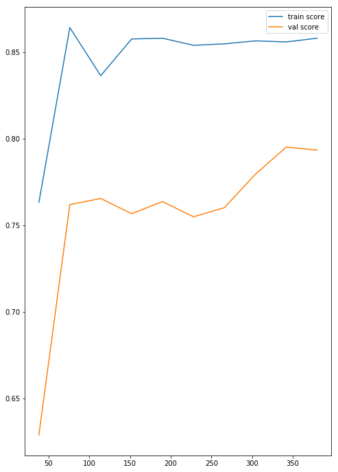

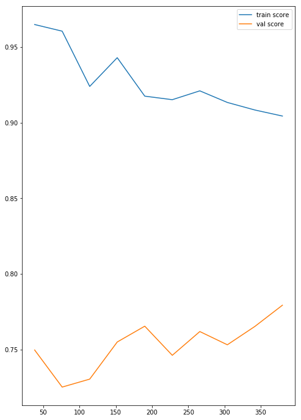

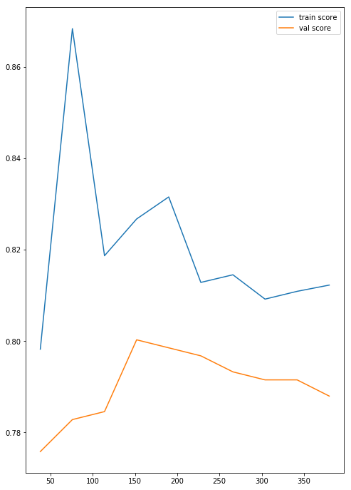

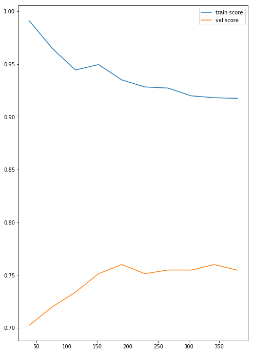

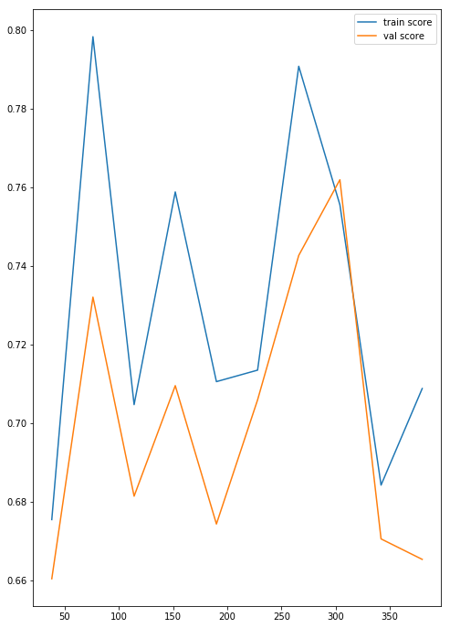

```python
for name, modele in list_modele.items():
    modele.fit(x_train,y_train)
    print(name)
    print(modele.score(x_test,y_test))
    N,train_score,val_score=learning_curve(modele,x_train,y_train,train_sizes=np.linspace(0.1,1,10))
    plt.figure(figsize=(8,12))
    plt.plot(N,train_score.mean(axis=1),label='train score')
    plt.plot(N,val_score.mean(axis=1),label='val score')
    plt.legend()
```